# Data Science and Business Analytics

# Project 1 - Python Foundations: FoodHub

# Jorge Ramon Vazquez Campero

## Table of Contents:

### Understanding the Structure of the Data

- Question 1: How many rows and columns are present in the data?
- Question 2: What are the datatypes of the different columns in the dataset?
- Question 3: Are there any missing values in the data?
- Question 4: Check the statistical summary of the data
- Question 5: How many orders are not rated?

### Exploratory Data Analysis (EDA)

#### Univariate Analysis

- Question 6: Explore all the variables and provide observations on their distributions.
- Question 7: Which are the top 5 restaurants in terms of the number of orders received?
- Question 8: Which is the most popular cuisine on weekends?
- Question 9: What percentage of the orders cost more than 20 dollars?
- Question 10: What is the mean order delivery time?
- Question 11: Find the IDs of the top 3 most frequent customers and the number of orders they placed.

#### Multivariate Analysis

- Question 12: Perform a multivariate analysis to explore relationships between the important variables in the dataset.
- Question 13: Find the restaurants fulfilling the criteria to get the promotional offer.
- Question 14: Find the net revenue generated by the company across all orders.
- Question 15: What percentage of orders take more than 60 minutes to get delivered from the time the order is placed?
- Question 16: How does the mean delivery time vary during weekdays and weekends?

### Conclusion and Recommendations

- Question 17: What are your conclusions from the analysis?

### Problem Statement

#### Description

##### Context

The number of restaurants in New York is increasing day by day. Lots of students and busy professionals rely on those restaurants due to their hectic lifestyles. Online food delivery service is a great option for them. It provides them with good food from their favorite restaurants. A food aggregator company FoodHub offers access to multiple restaurants through a single smartphone app.

The app allows the restaurants to receive a direct online order from a customer. The app assigns a delivery person from the company to pick up the order after it is confirmed by the restaurant. The delivery person then uses the map to reach the restaurant and waits for the food package. Once the food package is handed over to the delivery person, he/she confirms the pick-up in the app and travels to the customer's location to deliver the food. The delivery person confirms the drop-off in the app after delivering the food package to the customer. The customer can rate the order in the app. The food aggregator earns money by collecting a fixed margin of the delivery order from the restaurants.

#### Objective

The food aggregator company has stored the data of the different orders made by the registered customers in their online portal. They want to analyze the data to get a fair idea about the demand of different restaurants which will help them in enhancing their customer experience. Suppose you are hired as a Data Scientist in this company and the Data Science team has shared some of the key questions that need to be answered. Perform the data analysis to find answers to these questions that will help the company to improve the business.

#### Data Description

The data contains the different data related to a food order. The detailed data dictionary is given below.

Data Dictionary:

- **order_id**: Unique ID of the order
- **customer_id**: ID of the customer who ordered the food
- **restaurant_name**: Name of the restaurant
- **cuisine_type**: Cuisine ordered by the customer
- **cost**: Cost of the order
- **day_of_the_week**: Indicates whether the order is placed on a weekday or weekend (The weekday is from Monday to Friday and the weekend is Saturday and Sunday)
- **rating**: Rating given by the customer out of 5
- **food_preparation_time**: Time (in minutes) taken by the restaurant to prepare the food. This is calculated by taking the difference between the timestamps of the restaurant's order confirmation and the delivery person's pick-up confirmation.
- **delivery_time**: Time (in minutes) taken by the delivery person to deliver the food package. This is calculated by taking the difference between the timestamps of the delivery person's pick-up confirmation and drop-off information.

### Let us start by importing the required libraries

```python
# Installing the libraries with the specified version.
!pip install numpy==1.25.2 pandas==1.5.3 matplotlib==3.7.1 seaborn==0.13.1 plotly jupyter_contrib_nbextensions -q --user
```

**Note**: *After running the above cell, kindly restart the notebook kernel and run all cells sequentially from the start again.*

```python
# Import libraries for data manipulation.
import numpy as np
import pandas as pd

# Import libraries for data visualization.
import matplotlib.pyplot as plt
import seaborn as sns
import plotly.express as px

# Suppress warnings to prevent them from being displayed during code execution.
import warnings
warnings.filterwarnings('ignore')

# Enable the inline plotting of matplotlib figures directly within the notebook.
%matplotlib inline

# Set the display format for float values to three decimal places.
pd.set_option('display.float_format', lambda x: '%.3f' % x)
```

### Understanding the structure of the data

```python
# Since the data is stored in the same folder as the Jupyter Notebook file:
data = pd.read_csv('foodhub_order.csv')

# Copying data to another variable to avoid any changes to the original data.
df = data.copy()
```

```python
# Displaying the first five rows of the DataFrame 'df'
df.head()
```

|  | order_id | customer_id | restaurant_name | cuisine_type | cost_of_the_order | day_of_the_week | rating | food_preparation_time | delivery_time |
| --- | --- | --- | --- | --- | --- | --- | --- | --- | --- |
| 0 | 1477147 | 337525 | Hangawi | Korean | 30.750 | Weekend | Not given | 25 | 20 |
| 1 | 1477685 | 358141 | Blue Ribbon Sushi Izakaya | Japanese | 12.080 | Weekend | Not given | 25 | 23 |
| 2 | 1477070 | 66393 | Cafe Habana | Mexican | 12.230 | Weekday | 5 | 23 | 28 |
| 3 | 1477334 | 106968 | Blue Ribbon Fried Chicken | American | 29.200 | Weekend | 3 | 25 | 15 |
| 4 | 1478249 | 76942 | Dirty Bird to Go | American | 11.590 | Weekday | 4 | 25 | 24 |

### **Question 1:** How many rows and columns are present in the data? [0.5 mark]

```python
# Print the number of rows and columns in the DataFrame.
print("There are", df.shape[0], "rows and", df.shape[1], "columns.")
```

```
There are 1898 rows and 9 columns.
```

#### Observations:

It is worth noting that looking at the first 5 initial rows is not indicative of the whole dataset. However, when analyzing the first five initial rows of the dataset, several key insights can be identified:

- Both order and customer IDs display a lack of sequential pattern. This suggests that orders are processed independently, which could have implications for tracking and managing orders efficiently. However, it is very common to find this on many data sets as order IDs could be global.
- Additionally, the observed sample reveals a clear distinction between orders placed on weekdays and weekends, instead of specifiyig which day of the week are the orderes placed.
- Furthermore, while there's an option for customers to rate their orders with a numeric score, some ratings are missing, marked as 'Not given', also indicating varying levels of feedback participation.

### **Question 2:** What are the datatypes of the different columns in the dataset? (The info() function can be used) [0.5 mark]

```python
# Display a concise summary of the DataFrame df, including information about the data types and missing values.
# Additionally, this confirms the number of rows and columns present in the DataFrame.
df.info()
```

```
<class 'pandas.core.frame.DataFrame'>
RangeIndex: 1898 entries, 0 to 1897
Data columns (total 9 columns):
 #   Column                 Non-Null Count  Dtype
---  ------                 --------------  -----
 0   order_id               1898 non-null   int64
 1   customer_id            1898 non-null   int64
 2   restaurant_name        1898 non-null   object
 3   cuisine_type           1898 non-null   object
 4   cost_of_the_order      1898 non-null   float64
 5   day_of_the_week        1898 non-null   object
 6   rating                 1898 non-null   object
 7   food_preparation_time  1898 non-null   int64
 8   delivery_time          1898 non-null   int64
dtypes: float64(1), int64(4), object(4)
memory usage: 133.6+ KB
```

#### Observations:

Upon reviewing the dataset using the `info()` function, several key observations can be made:

- Each column contains 1,898 non-null values, indicating completeness in the available data and that there does not appear to be any missing data within the dataset at first glance.
- The data types assigned to most columns appear appropriate for the nature of the data they represent; order ID, customer ID, restaurant name, cuisine type, cost of the order, day of the week, food preparation time, and delivery time are all correctly assigned to their respective numerical or textual data types.
- However, a notable exception is observed in the rating column. This is currently classified as an object type. Although it was initially noted that the column contains numerical ratings ranging from 0 to 5, the presence of 'Not given' values suggests potential inconsistencies or missing values. Here, we should consider converting the rating column to a numerical data type and change the 'Not Given' to 'NaN' to facilitate consistent analysis and computation.

### **Question 3:** Are there any missing values in the data? If yes, treat them using an appropriate method. [1 mark]

We will perform a data sanity check to identify if there are any missing values present in each variable.This ensures the integrity of the dataset and allows for appropriate handling of missing values.

```python
# Checking missing values across each column
missing_values = df.isnull().sum()
missing_values
```

```
order_id                 0
customer_id              0
restaurant_name          0
cuisine_type             0
cost_of_the_order        0
day_of_the_week          0
rating                   0
food_preparation_time    0
delivery_time            0
dtype: int64
```

- The output indicates that there are no missing values present in any of the columns of the DataFrame.
- However, we already know that 'rating' has some inconsistencies with the "Not given" ratings.
- Let's first analyze the categorical variables and count each unique value in them.

```python
# Making a list of all categorical variables
cat_cols =  ['restaurant_name', 'cuisine_type', 'day_of_the_week', 'rating']

# Iterate through each categorical column and print the count of unique categorical levels, followed by a separator line.
for column in cat_cols:
    print(df[column].value_counts())
    print("-" * 50)
```

```
Shake Shack                  219
The Meatball Shop            132
Blue Ribbon Sushi            119
Blue Ribbon Fried Chicken     96
Parm                          68
                            ...
Sushi Choshi                   1
Dos Caminos Soho               1
La Follia                      1
Philippe Chow                  1
'wichcraft                     1
Name: restaurant_name, Length: 178, dtype: int64
--------------------------------------------------
American          584
Japanese          470
Italian           298
Chinese           215
Mexican            77
Indian             73
Middle Eastern     49
Mediterranean      46
Thai               19
French             18
Southern           17
Korean             13
Spanish            12
Vietnamese          7
Name: cuisine_type, dtype: int64
--------------------------------------------------
Weekend    1351
Weekday     547
Name: day_of_the_week, dtype: int64
--------------------------------------------------
Not given    736
5            588
4            386
3            188
Name: rating, dtype: int64
--------------------------------------------------
```

- The restaurant "Shake Shack" has the highest number of orders, followed by "The Meatball Shop" and "Blue Ribbon Sushi", indicating their popularity among customers.
- Among the cuisine types, American and Japanese cuisines are the most popular, with 584 and 470 orders respectively, followed by Italian cuisine with 298 orders.
- The dataset contains more orders placed during weekends (1351) compared to weekdays (547), suggesting a higher demand for food delivery services during weekends.
- The rating distribution shows that a significant number of orders (736) have missing ratings marked as "Not given", followed by a substantial number of orders with a rating of 5 (588), indicating a general satisfaction level among customers. However, there are also orders with lower ratings of 4 and 3.

```python
# Confirming the count of 'Not given' in rating column
notgiventimes = df['rating'].value_counts().get('Not given')
print('Not given is found', notgiventimes, 'times in the rating column')
```

```
Not given is found 736 times in the rating column
```

```python
# Displaying the percentage distribution of ratings
rating_percentages = df['rating'].value_counts(normalize=True) * 100
print("\nPercentage distribution of ratings:\n", rating_percentages)
```

```
Percentage distribution of ratings:
 Not given   38.778
5           30.980
4           20.337
3            9.905
Name: rating, dtype: float64
```

- The count of "Not given" ratings in the 'rating' column is 736, indicating that a significant portion of the ratings are missing in the dataset.
- The percentage distribution of ratings reveals that approximately 38.78% of the ratings are marked as "Not given", followed by 30.98% with a rating of 5, 20.34% with a rating of 4, and 9.90% with a rating of 3.
- The high percentage of "Not given" ratings suggests a potential issue with data completeness or user feedback.

```python
# Copying data to another variable to avoid any changes to original data
df_numrating_copy = df.copy()

# Create a new column to store the numerical values by copying an existing column
df_numrating_copy['rating_num'] = df_numrating_copy['rating']

# Display the DataFrame with the new column
df_numrating_copy
```

|  | order_id | customer_id | restaurant_name | cuisine_type | cost_of_the_order | day_of_the_week | rating | food_preparation_time | delivery_time | rating_num |
| --- | --- | --- | --- | --- | --- | --- | --- | --- | --- | --- |
| 0 | 1477147 | 337525 | Hangawi | Korean | 30.750 | Weekend | Not given | 25 | 20 | Not given |
| 1 | 1477685 | 358141 | Blue Ribbon Sushi Izakaya | Japanese | 12.080 | Weekend | Not given | 25 | 23 | Not given |
| 2 | 1477070 | 66393 | Cafe Habana | Mexican | 12.230 | Weekday | 5 | 23 | 28 | 5 |
| 3 | 1477334 | 106968 | Blue Ribbon Fried Chicken | American | 29.200 | Weekend | 3 | 25 | 15 | 3 |
| 4 | 1478249 | 76942 | Dirty Bird to Go | American | 11.590 | Weekday | 4 | 25 | 24 | 4 |
| ... | ... | ... | ... | ... | ... | ... | ... | ... | ... | ... |
| 1893 | 1476701 | 292602 | Chipotle Mexican Grill $1.99 Delivery | Mexican | 22.310 | Weekend | 5 | 31 | 17 | 5 |
| 1894 | 1477421 | 397537 | The Smile | American | 12.180 | Weekend | 5 | 31 | 19 | 5 |
| 1895 | 1477819 | 35309 | Blue Ribbon Sushi | Japanese | 25.220 | Weekday | Not given | 31 | 24 | Not given |
| 1896 | 1477513 | 64151 | Jack's Wife Freda | Mediterranean | 12.180 | Weekday | 5 | 23 | 31 | 5 |
| 1897 | 1478056 | 120353 | Blue Ribbon Sushi | Japanese | 19.450 | Weekend | Not given | 28 | 24 | Not given |

1898 rows × 10 columns

```python
# replacing values in the numerical column with nan
df_numrating_copy['rating_num'] = df_numrating_copy['rating_num'].replace(['Not given'],np.nan)

# changing the data type to float
df_numrating_copy['rating_num'] = df_numrating_copy['rating_num'].astype(float)
df_numrating_copy.info()
```

```
<class 'pandas.core.frame.DataFrame'>
RangeIndex: 1898 entries, 0 to 1897
Data columns (total 10 columns):
 #   Column                 Non-Null Count  Dtype
---  ------                 --------------  -----
 0   order_id               1898 non-null   int64
 1   customer_id            1898 non-null   int64
 2   restaurant_name        1898 non-null   object
 3   cuisine_type           1898 non-null   object
 4   cost_of_the_order      1898 non-null   float64
 5   day_of_the_week        1898 non-null   object
 6   rating                 1898 non-null   object
 7   food_preparation_time  1898 non-null   int64
 8   delivery_time          1898 non-null   int64
 9   rating_num             1162 non-null   float64
dtypes: float64(2), int64(4), object(4)
memory usage: 148.4+ KB
```

```python
# Checking for missing values again
df_numrating_copy.isnull().sum()
```

```
order_id                   0
customer_id                0
restaurant_name            0
cuisine_type               0
cost_of_the_order          0
day_of_the_week            0
rating                     0
food_preparation_time      0
delivery_time              0
rating_num               736
dtype: int64
```

```python
# Confirming the count of missing values in rating column
missingvals = df_numrating_copy['rating_num'].isna().sum()
print('Number of missing values in the rating column:', missingvals);
```

```
Number of missing values in the rating column: 736
```

### **Question 4:** Check the statistical summary of the data. What is the minimum, average, and maximum time it takes for food to be prepared once an order is placed? [2 marks]

```python
# Generate descriptive statistics for all columns in the DataFrame and transpose the result for better readability.
df_numrating_copy.describe(include='all').T
```

|  | count | unique | top | freq | mean | std | min | 25% | 50% | 75% | max |
| --- | --- | --- | --- | --- | --- | --- | --- | --- | --- | --- | --- |
| order_id | 1898.000 | NaN | NaN | NaN | 1477495.500 | 548.050 | 1476547.000 | 1477021.250 | 1477495.500 | 1477969.750 | 1478444.000 |
| customer_id | 1898.000 | NaN | NaN | NaN | 171168.478 | 113698.140 | 1311.000 | 77787.750 | 128600.000 | 270525.000 | 405334.000 |
| restaurant_name | 1898 | 178 | Shake Shack | 219 | NaN | NaN | NaN | NaN | NaN | NaN | NaN |
| cuisine_type | 1898 | 14 | American | 584 | NaN | NaN | NaN | NaN | NaN | NaN | NaN |
| cost_of_the_order | 1898.000 | NaN | NaN | NaN | 16.499 | 7.484 | 4.470 | 12.080 | 14.140 | 22.297 | 35.410 |
| day_of_the_week | 1898 | 2 | Weekend | 1351 | NaN | NaN | NaN | NaN | NaN | NaN | NaN |
| rating | 1898 | 4 | Not given | 736 | NaN | NaN | NaN | NaN | NaN | NaN | NaN |
| food_preparation_time | 1898.000 | NaN | NaN | NaN | 27.372 | 4.632 | 20.000 | 23.000 | 27.000 | 31.000 | 35.000 |
| delivery_time | 1898.000 | NaN | NaN | NaN | 24.162 | 4.973 | 15.000 | 20.000 | 25.000 | 28.000 | 33.000 |
| rating_num | 1162.000 | NaN | NaN | NaN | 4.344 | 0.741 | 3.000 | 4.000 | 5.000 | 5.000 | 5.000 |

```python
# Calculate the minimum, average, and maximum food preparation times across the entire dataset
min_fpt = df_numrating_copy['food_preparation_time'].min()
avg_fpt = df_numrating_copy['food_preparation_time'].mean()
max_fpt = df_numrating_copy['food_preparation_time'].max()

# Display the statistics
print("Minimum Food Preparation Time:", min_fpt)
print("Average Food Preparation Time:", avg_fpt)
print("Maximum Food Preparation Time:", max_fpt)
```

```
Minimum Food Preparation Time: 20
Average Food Preparation Time: 27.371970495258168
Maximum Food Preparation Time: 35
```

#### Observations:

- The statistical summary of the entire data was conducted using the `describe()` function.
- The minimum food preparation time is 20 minutes, the average is approximately 27.37 minutes, and the maximum is 35 minutes.
- These findings suggest a reasonable range for food preparation times:
  - The minimum preparation time of 20 minutes indicates efficient kitchen operations or simpler dishes.
  - An average preparation time of 27.37 minutes provides insight into typical durations for order fulfillment.
  - The maximum preparation time of 35 minutes suggests potential outliers or instances of delays in preparation, but it remains within an acceptable range.
- The large standard deviation in customer_id signifies a diverse customer base, as indicated by the wide range of customer IDs.
- The average cost of an order is approximately $16.50, with significant variability. This suggests a variety of meal price points offered by different restaurants.

### **Question 5:** How many orders are not rated? [1 mark]

```python
# As we mentioned before, we can get an overall description of how many times a value is present in the DataFrame through value_counts()
df['rating'].value_counts()
```

```
Not given    736
5            588
4            386
3            188
Name: rating, dtype: int64
```

```python
# Analyzing the normalized (percentage) of how many times a value is present in the DataFrame.
df['rating'].value_counts(normalize=True) * 100
```

```
Not given   38.778
5           30.980
4           20.337
3            9.905
Name: rating, dtype: float64
```

```python
# Confirming the count of 'Not given' in rating column in a more direct and explicit way
notgiventimes = df['rating'].value_counts().get('Not given')
print('Not given is found ', notgiventimes, ' times in the rating column')
```

```
Not given is found  736  times in the rating column
```

#### Observations:

- The analysis accurately identifies the number of orders that are not rated by using the `value_counts()` method.
- It is observed that 'Not given' ratings occur 736 times, which constitutes approximately 38.78% of the total ratings.
- The substantial proportion of unrated orders highlights a significant portion of the dataset where customer feedback is missing.
- This high percentage of missing ratings (nearly 40%) underscores the importance of addressing these gaps for more robust and reliable data analysis.
- However, despite the missing ratings, retaining these entries is advisable to maintain the dataset's uniformity and completeness at least for the data that does not directly involve the ratings. This approach allows for a more dynamic data analysis while keeping accuracy in our observations.

### Exploratory Data Analysis (EDA)

### **Question 6:** Explore all the variables and provide observations on their distributions. (Generally, histograms, boxplots, countplots, etc. are used for univariate exploration.) [9 marks]

```python
# Displaying a concise summary of the DataFrame df, including information about the data types and missing values.
df.info()
```

```
<class 'pandas.core.frame.DataFrame'>
RangeIndex: 1898 entries, 0 to 1897
Data columns (total 9 columns):
 #   Column                 Non-Null Count  Dtype
---  ------                 --------------  -----
 0   order_id               1898 non-null   int64
 1   customer_id            1898 non-null   int64
 2   restaurant_name        1898 non-null   object
 3   cuisine_type           1898 non-null   object
 4   cost_of_the_order      1898 non-null   float64
 5   day_of_the_week        1898 non-null   object
 6   rating                 1898 non-null   object
 7   food_preparation_time  1898 non-null   int64
 8   delivery_time          1898 non-null   int64
dtypes: float64(1), int64(4), object(4)
memory usage: 133.6+ KB
```

#### Order ID

```python
# With Order_ID being numerical in nature, we can get some insights if the Order ID has any duplicate values.
# We expect to see no duplicate values as each order should have a unique Oder ID
unique_orderid = df['order_id'].nunique()
print('There are ', unique_orderid, 'unique order IDs. This means that there are no duplicate Order IDs'  )
```

```
There are  1898 unique order IDs. This means that there are no duplicate Order IDs
```

#### Customer ID

```python
# Here we can also get an insight to find out if there are certain customers that use our service more than others.
# We can do this by using the same method.
unique_customerid = df['customer_id'].nunique()
print('There is a total of', unique_customerid, 'customers. This means that', unique_customerid, 'customers use our service and have placed orders more than once.')
```

[output not shown]

```python
# Displaying the frequency of the unique customers and how many orders they have placed.
CustomerCounts = df['customer_id'].value_counts()
CustomerCounts
```

```
52832     13
47440     10
83287      9
250494     8
259341     7
          ..
385426     1
254913     1
289597     1
74412      1
397537     1
Name: customer_id, Length: 1200, dtype: int64
```

```python
# Generate descriptive statistics for Customer ID.
df['customer_id'].describe()
```

```
count     1898.000
mean    171168.478
std     113698.140
min       1311.000
25%      77787.750
50%     128600.000
75%     270525.000
max     405334.000
Name: customer_id, dtype: float64
```

- We can see that there are repeated customers who have placed orders more than once. Specifically, the analysis reveals that the majority of customers have placed only one order, with a minimum of 1 order per customer.
- However, some customers have shown higher engagement with the service, as evidenced by customer 52832, who has placed the maximum of 13 orders. This variation in the number of orders per customer highlights the diverse usage patterns among customers.

#### Restaurant Name

```python
# Analyzing the categorical variable of Restaurant name for any pattern.
unique_restname = df['restaurant_name'].nunique()
print('There is a total of', unique_restname, 'unique restaurants where customers place their orders')

# Display the frequency of each restaurant in the data set.
RestaurantCounts = df['restaurant_name'].value_counts()
RestaurantCounts
```

```
There is a total of 178 unique restaurants where customers place their orders
```

```
Shake Shack                  219
The Meatball Shop            132
Blue Ribbon Sushi            119
Blue Ribbon Fried Chicken     96
Parm                          68
                            ...
Sushi Choshi                   1
Dos Caminos Soho               1
La Follia                      1
Philippe Chow                  1
'wichcraft                     1
Name: restaurant_name, Length: 178, dtype: int64
```

```python
# Generate descriptive statistics for the restaurants column.
df['restaurant_name'].describe()
```

```
count            1898
unique            178
top       Shake Shack
freq              219
Name: restaurant_name, dtype: object
```

- There are 178 unique restaurants where customers place their orders.
- Some restaurants have received more orders than others, with Shake Shack leading with 219 orders, followed by The Meatball Shop, Blue Ribbon Sushi, and Blue Ribbon Fried Chicken, among others.
- This variation in order frequency among restaurants suggests potential differences in popularity, proximity to customers, familiarity, whether they are franchises, or the quality of the food. It could also be related to the ratings given by customers, indicating areas for further exploration.

#### Cuisine Type

```python
# Count the number of unique cuisine types
unique_cuisinetype = df['cuisine_type'].nunique()
print('There is a total of', unique_cuisinetype, 'different cuisine types where customers chose to order from.')

# Display the frequency of each cusine type in the data set.
CuisineCounts = df['cuisine_type'].value_counts()
CuisineCounts
```

```
There is a total of 14 different cuisine types where customers chose to order from.
```

```
American          584
Japanese          470
Italian           298
Chinese           215
Mexican            77
Indian             73
Middle Eastern     49
Mediterranean      46
Thai               19
French             18
Southern           17
Korean             13
Spanish            12
Vietnamese          7
Name: cuisine_type, dtype: int64
```

```python
# Generate descriptive statistics for cuisine type
df['cuisine_type'].describe()
```

```
count         1898
unique          14
top       American
freq           584
Name: cuisine_type, dtype: object
```

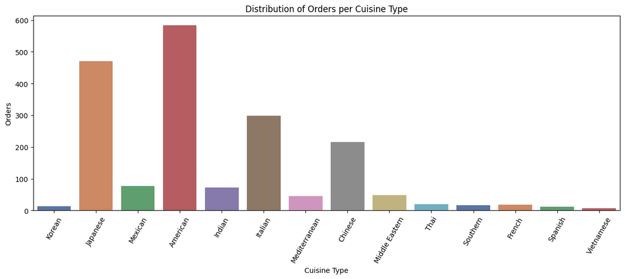

```python
# The best way to helps us understand data distribution in this scenario is to use a Bar Graph since it will show us the count
# of orders per cuisine type

plt.figure(figsize = (15, 5))                                   # Plot size
sns.countplot(data = df, x = 'cuisine_type', palette='deep');   # Countplot of cuisine types
plt.title("Distribution of Orders per Cuisine Type")            # Title of the Graph
plt.xlabel('Cuisine Type')                                      # Title of the x-axis
plt.ylabel('Orders')                                            # Title of the y-axis
plt.xticks(rotation=60);                                        # Rotation of the x axis legend for clarity
plt.show()
```

- Compared to the previous values, here we can actually show the distribution of the the orders per a variable.
- The top 5 cuisine types with the most orders are American (584), Japanese (470), Italian (298), Chinese (215), and Mexican (77).
- This distribution may reflect customer preferences based on cultural influences, demographics, availability, price, or perceived quality of the food.

#### Cost of the Order

```python
# Generate descriptive statistics for cost of the order
df['cost_of_the_order'].describe()
```

```
count   1898.000
mean      16.499
std        7.484
min        4.470
25%       12.080
50%       14.140
75%       22.297
max       35.410
Name: cost_of_the_order, dtype: float64
```

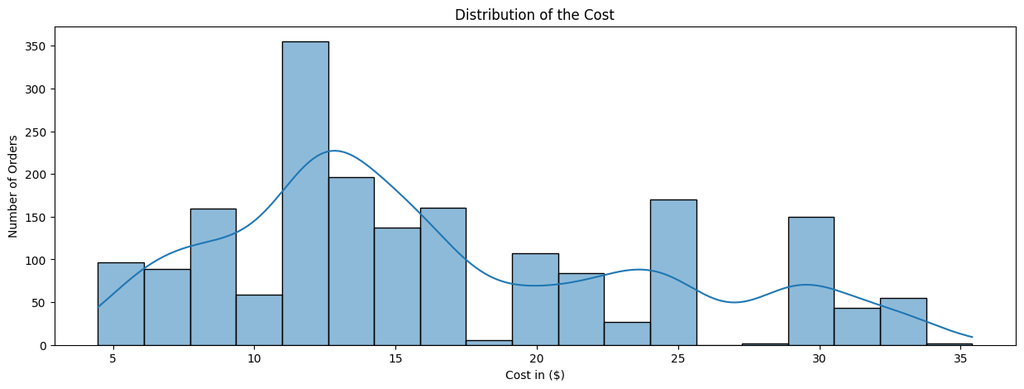

```python
# Visualize the distribution of the cost of the order using a histogram showing the number of observations for different price ranges.

plt.figure(figsize = (15, 5))                           # Plot size
sns.histplot(data=df,x='cost_of_the_order', kde=True);  # Histogram of cuisine types
plt.title("Distribution of the Cost")                   # Title of the Graph
plt.xlabel('Cost in ($)')                                 # Title of the x-axis
plt.ylabel('Number of Orders')                          # Title of the y-axis
plt.show()
```

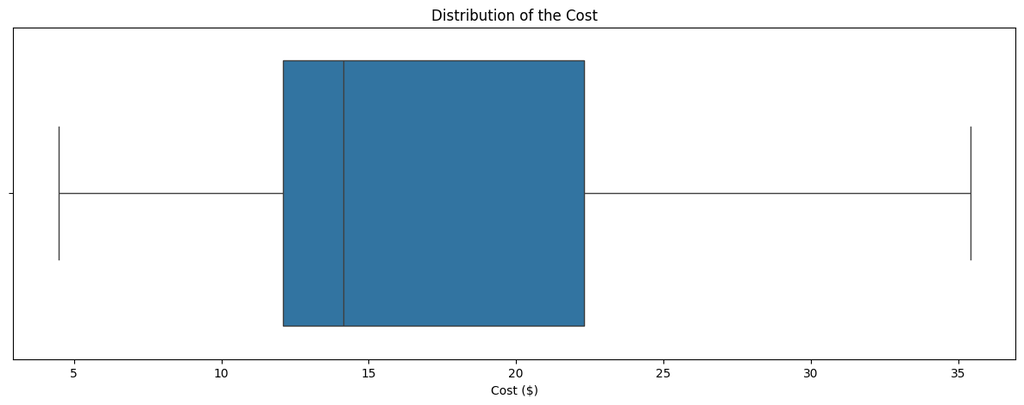

```python
## Visualize the distribution of the cost of the order using a box plot.

plt.figure(figsize = (15, 5))                   # Plot size
sns.boxplot(data=df,x='cost_of_the_order');     # Boxplot of cuisine types
plt.title("Distribution of the Cost")           # Title of the Graph
plt.xlabel('Cost ($)')                         # Title of the x-axis
plt.show()
```

- The histogram and box plot illustrate the distribution and skewness of the cost per number of orders.
- The data is slightly right-skewed, with a majority of orders having a cost below ≈`$23`.
- The average order cost is approximately `$16.50`, as indicated by the descriptive statistics.

#### Day of the Week

```python
# Check the unique values of days of the week. We expect Weekdays and Weekends.
unique_weekdays = df['day_of_the_week'].nunique()
print('Orders are fivided into', unique_weekdays, 'categories; Weekday and Weekend.')
```

```
Orders are fivided into 2 categories; Weekday and Weekend.
```

```python
# Count the occurrences of each unique value in the 'day_of_the_week' column
DayoftheWeekCounts = df['day_of_the_week'].value_counts()
DayoftheWeekCounts
```

```
Weekend    1351
Weekday     547
Name: day_of_the_week, dtype: int64
```

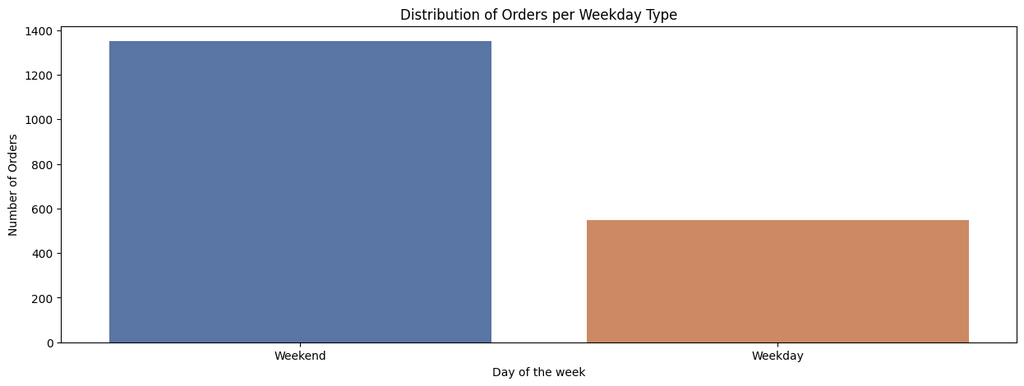

```python
# Visualizing the data distribution of Orders Per week day type by using a Bar Graph.

plt.figure(figsize = (15, 5))                                                # Plot size
sns.countplot(data = df, x = 'day_of_the_week', palette='deep');             # Countplot of cuisine types
plt.title("Distribution of Orders per Weekday Type")                         # Title of the Graph
plt.xlabel('Day of the week')                                                # Title of the x-axis
plt.ylabel('Number of Orders')                                               # Title of the y-axis
plt.show()
```

- The bar graph helps us understand the distribution of the orders placed on either a weekday or a weekend day.
- It is evident from both the graph and the value counts that a majority of the orders (1351) are placed on weekends, while the remaining (547) are placed on weekdays.
- This could be attributed to various factors such as people preferring to dine out or order in during weekends due to social gatherings, leisure time, or simply wanting to treat themselves after a busy week.
- Understanding this trend could be crucial for FoodHub's business strategy, potentially leading to targeted promotions or offers during weekends to capitalize on the increased demand.

#### Rating

```python
# Check the unique values of ratings. We expect to have 4 categories when using the original data frame
# with the categorical values.
unique_ratings = df['rating'].nunique()
print('There are only', unique_ratings, 'unique rating categories given. Although the ratings are from 1-5, we have ratings of 3, 4, 5, and Not given.')
```

```
There are only 4 unique rating categories given. Although the ratings are from 1-5, we have ratings of 3, 4, 5, and Not given.
```

```python
# Count the occurrences of each unique value in the 'rating' column of the DataFrame. We will be using the categorical data
# to illustrate better the distribution.
rating_counts = df['rating'].value_counts()
rating_counts
```

```
Not given    736
5            588
4            386
3            188
Name: rating, dtype: int64
```

```python
# Generate descriptive statistics for the categorical data of rating.
df['rating'].describe()
```

```
count          1898
unique            4
top       Not given
freq            736
Name: rating, dtype: object
```

```python
# Generate descriptive statistics for the numerical data of rating for comparison.
df_numrating_copy['rating_num'].describe()
```

```
count   1162.000
mean       4.344
std        0.741
min        3.000
25%        4.000
50%        5.000
75%        5.000
max        5.000
Name: rating_num, dtype: float64
```

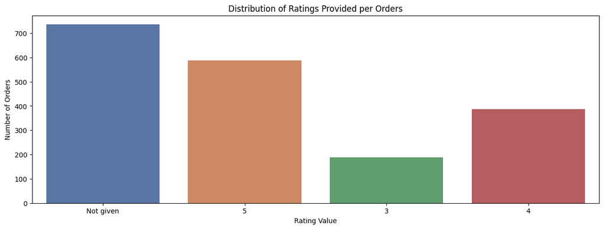

```python
# The best way to understand data distribution in this scenario is to use a bar graph since it will show us how many
# orders placed were assigned what rating. Here is the bar plot for the categorical data.

plt.figure(figsize=(15, 5))                               # Plot size
sns.countplot(data=df, x='rating', palette='deep');       # Countplot of cuisine types
plt.title("Distribution of Ratings Provided per Orders")  # Title of the Graph
plt.xlabel('Rating Value')                                # Title of the x-axis
plt.ylabel('Number of Orders')                            # Title of the y-axis
plt.show()
```

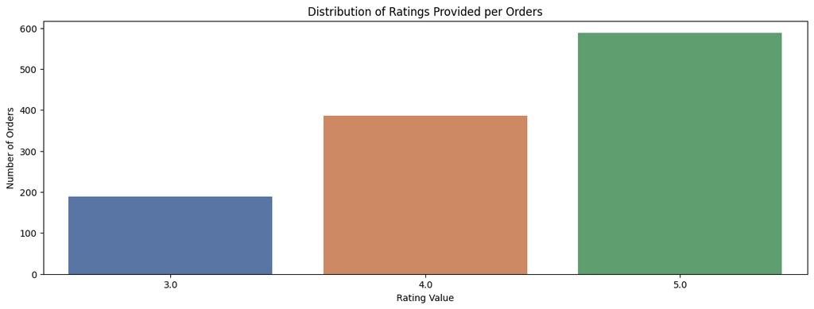

```python
# The best way to understand data distribution in this scenario is to use a bar graph since it will show us how many
# orders placed were assigned what rating. Here is the bar plot for the numerical data.

plt.figure(figsize=(15, 5))                                            # Plot size
sns.countplot(data=df_numrating_copy, x='rating_num', palette='deep'); # Countplot of cuisine types
plt.title("Distribution of Ratings Provided per Orders")               # Title of the Graph
plt.xlabel('Rating Value')                                             # Title of the x-axis
plt.ylabel('Number of Orders')                                         # Title of the y-axis
plt.show()
```

#### Food Preparation Time

```python
# Check the number of unique values for Food Preparation Time (fpt).
unique_fpt = df['food_preparation_time'].nunique()
print('There are', unique_fpt, 'unique preparation times.')
```

```
There are 16 unique preparation times.
```

```python
# Count the occurrences of each unique value of Food Preparation Time (fpt).
FptTime = df['food_preparation_time'].value_counts()
FptTime
```

```
21    135
23    123
27    123
22    123
28    121
24    121
20    119
30    119
33    118
35    117
31    116
26    115
25    113
34    113
32    113
29    109
Name: food_preparation_time, dtype: int64
```

```python
# Generate descriptive statistics for Food Preparation Time (fpt).
df['food_preparation_time'].describe()
```

```
count   1898.000
mean      27.372
std        4.632
min       20.000
25%       23.000
50%       27.000
75%       31.000
max       35.000
Name: food_preparation_time, dtype: float64
```

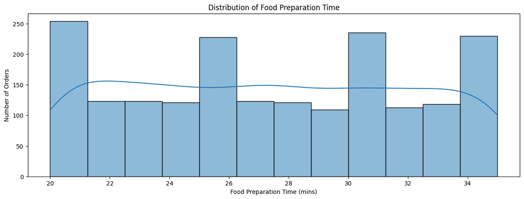

```python
# Use a histogram to understand the distribution of Food Preparation Time.

plt.figure(figsize=(15, 5))                                  # Plot size
sns.histplot(data=df, x='food_preparation_time', kde=True);  # Histogram for food preparation time
plt.title("Distribution of Food Preparation Time")           # Title of the Graph
plt.xlabel('Food Preparation Time (mins)')                   # Title of the x-axis
plt.ylabel('Number of Orders')                               # Title of the y-axis
plt.show()
```

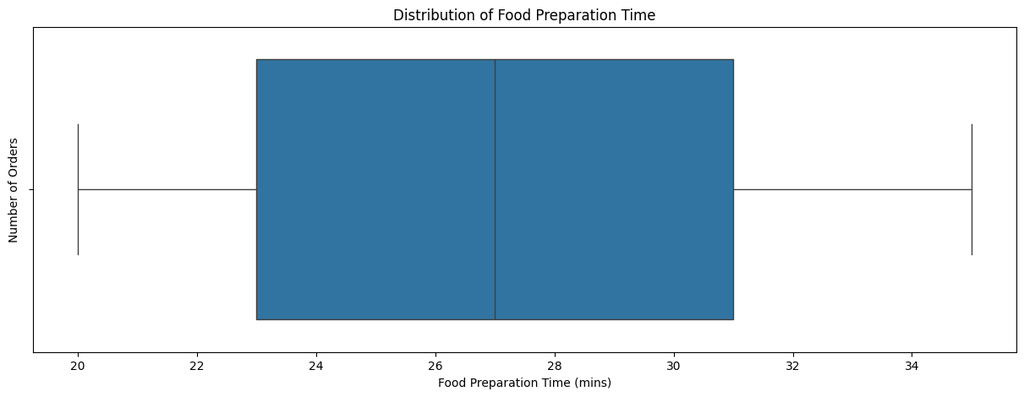

```python
# Use a boxplot to understand the distribution and skewness of the data.

plt.figure(figsize=(15, 5))                         # Plot size
sns.boxplot(data=df, x='food_preparation_time');    # Boxplot for Food Preparation Time
plt.title("Distribution of Food Preparation Time")  # Title of the Graph
plt.xlabel('Food Preparation Time (mins)')          # Title of the x-axis
plt.ylabel('Number of Orders')                      # Title of the y-axis
plt.show()
```

```python
# Check the skewness of the Food Preparation Time (fpt) distribution.
fpt_skewness = df['food_preparation_time'].skew()

if fpt_skewness > 0:
    print("Food preparation time is right-skewed (positively skewed) =", round(fpt_skewness,3))
else:
    print("Food preparation time is left-skewed (negatively skewed) =", round(fpt_skewness,3))
```

```
Food preparation time is right-skewed (positively skewed) = 0.036
```

- The statistical summary of the data was generated using the describe() function. The minimum, average, and maximum food preparation times are 20 minutes, 27.372 minutes, and 35 minutes, respectively.
- We observed that there are only 16 unique food preparation times. The occurrences of each unique value were counted, revealing a relatively uniform distribution across these times.
- The histogram of the food preparation times shows four distinct peaks around 20, 25, 30, and 34 minutes, suggesting a multimodal distribution. This indicates different patterns or processes related to food preparation times.
- The boxplot confirms that the data is relatively uniform, with no significant outliers.
- The skewness value of 0.036 indicates a nearly symmetric distribution with a slight positive skew.
- Overall, the distribution of food preparation times appears to be nearly symmetric with multiple modes, reflecting various operational efficiencies and preparation complexities in the dataset.

#### Delivery Time

```python
# Check the number of unique values for Delivery Time (dt).
unique_dt = df['delivery_time'].nunique()
print('There are', unique_dt, 'unique delivery times.')
```

```
There are 19 unique delivery times.
```

```python
# Count the occurrences of each unique value of Delivery Time (dt).
dtTime = df['delivery_time'].value_counts()
dtTime
```

```
24    162
28    148
29    148
26    141
27    138
30    133
25    120
19     90
16     90
20     88
15     87
22     85
18     83
21     81
17     78
23     77
32     59
33     49
31     41
Name: delivery_time, dtype: int64
```

```python
# Generate descriptive statistics for Delivery Time (dt).
df['delivery_time'].describe()
```

```
count   1898.000
mean      24.162
std        4.973
min       15.000
25%       20.000
50%       25.000
75%       28.000
max       33.000
Name: delivery_time, dtype: float64
```

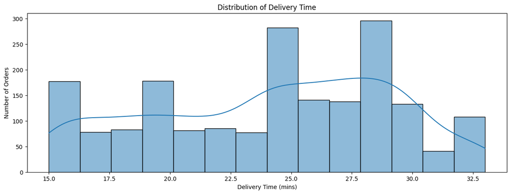

```python
# Use a histogram to understand the distribution of Delivery Time.

plt.figure(figsize=(15, 5))                         # Plot size
sns.histplot(data=df, x='delivery_time', kde=True)  # Histogram for delivery time
plt.title("Distribution of Delivery Time")          # Title of the Graph
plt.xlabel('Delivery Time (mins)')                  # Title of the x-axis
plt.ylabel('Number of Orders')                      # Title of the y-axis
plt.show()
```

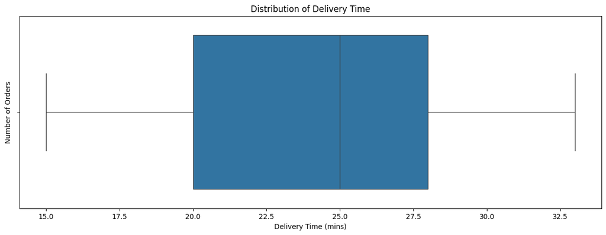

```python
# Use a boxplot to understand the distribution and skewness of the data.

plt.figure(figsize=(15, 5))                 # Plot size
sns.boxplot(data=df, x='delivery_time')     # Boxplot for delivery time
plt.title("Distribution of Delivery Time")  # Title of the Graph
plt.xlabel('Delivery Time (mins)')          # Title of the x-axis
plt.ylabel('Number of Orders')              # Title of the y-axis
plt.show()
```

```python
# Check the skewness of the Delivery Time (dt) distribution.
dt_skewness = df['delivery_time'].skew()

if dt_skewness > 0:
    print("The delivery time is right-skewed (positively skewed) =", dt_skewness)
else:
    print("The delivery time is left-skewed (negatively skewed) =", dt_skewness)
```

```
The delivery time is left-skewed (negatively skewed) = -0.23653630513419896
```

- The minimum, average, and maximum delivery times are 15 minutes, 24.162 minutes, and 33 minutes, respectively.
- We observed that there are 19 unique delivery times. The occurrences of each unique value were counted, revealing a relatively varied distribution across these times.
- The histogram of the delivery times shows several peaks, indicating a multimodal distribution. This suggests different patterns or processes related to delivery times.
- The boxplot confirms the variability in the data, with no significant outliers.
- The skewness value of -0.236 indicates a slight negative skew.

### **Question 7**: Which are the top 5 restaurants in terms of the number of orders received? [1 mark]

```python
# This was part of our previous observations, but we can gather the information again by running the following:

RestaurantCounts = df['restaurant_name'].value_counts()
RestaurantCounts
```

```
Shake Shack                  219
The Meatball Shop            132
Blue Ribbon Sushi            119
Blue Ribbon Fried Chicken     96
Parm                          68
                            ...
Sushi Choshi                   1
Dos Caminos Soho               1
La Follia                      1
Philippe Chow                  1
'wichcraft                     1
Name: restaurant_name, Length: 178, dtype: int64
```

```python
# Let's confirm with a more direct approach to find the top 5 restaurants:

Top5RestaurantCounts = df['restaurant_name'].value_counts().head(5)
print("The top 5 restaurants in terms of the number of orders received are:\n")
Top5RestaurantCounts
```

```
The top 5 restaurants in terms of the number of orders received are:
```

```
Shake Shack                  219
The Meatball Shop            132
Blue Ribbon Sushi            119
Blue Ribbon Fried Chicken     96
Parm                          68
Name: restaurant_name, dtype: int64
```

#### Observations:

- Using the value_counts() function, we identified the top five restaurants in terms of the number of orders received. The results are as follows:
  - Shake Shack: 219 orders
  - The Meatball Shop: 132 orders
  - Blue Ribbon Sushi: 119 orders
  - Blue Ribbon Fried Chicken: 96 orders
  - Parm: 68 orders
- These findings indicate that Shake Shack is the most popular restaurant among customers, followed by The Meatball Shop and Blue Ribbon Sushi.
- This information can help the company understand customer preferences and potentially focus on partnerships or promotions with these top-performing restaurants.

### **Question 8**: Which is the most popular cuisine on weekends? [1 mark]

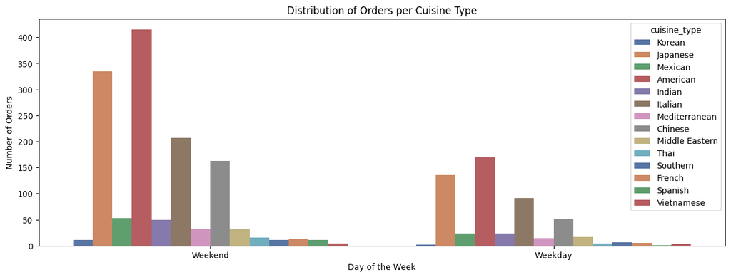

```python
# We can gather this information by using a bar plot, grouping the orders by days of the week and cuisine type.

plt.figure(figsize=(15, 5))   # Plot size
sns.countplot(data=df, x='day_of_the_week', hue="cuisine_type", palette='deep');   # Boxplot of cuisine types
plt.title("Distribution of Orders per Cuisine Type")   # Title of the Graph
plt.xlabel('Day of the Week')   # Title of the x-axis
plt.ylabel('Number of Orders')   # Title of the y-axis
plt.show()
```

```python
# Based on the above graph, American cuisine appears to be the most popular on weekends. Let's confirm this using .value_counts().idxmax().

popular_cuisine_weekends = df[df['day_of_the_week'] == 'Weekend']['cuisine_type'].value_counts()

most_popular_cuisine = popular_cuisine_weekends.idxmax()
count_popular_cuisine_weekends = popular_cuisine_weekends.max()

print("The most popular cuisine on weekends is", most_popular_cuisine, "cuisine with", count_popular_cuisine_weekends, "orders.")
```

```
The most popular cuisine on weekends is American cuisine with 415 orders.
```

#### Observations:

- The bar plot visually shows the distribution of orders per cuisine type for different days of the week. It is evident that American cuisine is the most popular on weekends.
- By further analyzing the data using `.value_counts().idxmax()`, we confirmed that American cuisine is the most popular on weekends, with 415 orders.
- This insight can help the company understand customer preferences during weekends, allowing for targeted promotions.

### **Question 9**: What percentage of the orders cost more than 20 dollars? [2 marks]

```python
# The best way to get the percentage is by first obtaining the number of orders above $20, then multiplying by 100 and dividing by the total number of observations (1898).

cost_greater_than_20 = df[df['cost_of_the_order'] > 20].shape[0]
print('The number of total orders that cost above $20 is:', cost_greater_than_20)
```

```
The number of total orders that cost above $20 is: 555
```

```python
# Calculate the percentage of orders that cost more than $20.

percentage_greater_than_20 = (cost_greater_than_20 * 100) / df.shape[0]
print(round(percentage_greater_than_20, 3), '% of the orders cost more than $20')
```

```
29.241 % of the orders cost more than $20
```

```python
# To validate our calculations, we can directly calculate the percentage using the mean function and then multiplying by 100.

percentage_cost_over_20 = (df['cost_of_the_order'] > 20).mean() * 100
print(round(percentage_cost_over_20, 3), '% of the orders cost more than $20')
```

```
29.241 % of the orders cost more than $20
```

#### Observations:

- We determined that 29.24% of the orders cost more than `$20`. This was calculated by obtaining the number of orders above `$20`, multiplying by 100, and dividing by the total number of observations (1,898).
- To validate our calculation, we used the mean function and multiplied by 100, confirming the result.
- This indicates that a significant portion of the orders cost more than `$20`, though it is not the majority. This insight can help the company understand pricing dynamics and potentially adjust strategies to cater to customers who tend to spend more.

### **Question 10**: What is the mean order delivery time? [1 mark]

```python
# Generate descriptive statistics for Delivery Time (dt).
df['delivery_time'].describe()
```

```
count   1898.000
mean      24.162
std        4.973
min       15.000
25%       20.000
50%       25.000
75%       28.000
max       33.000
Name: delivery_time, dtype: float64
```

```python
# We can also obtain the mean using a more direct approach.

mean_dt = df['delivery_time'].mean()
print('The mean order delivery time is', round(mean_dt, 3), 'minutes.')
```

```
The mean order delivery time is 24.162 minutes.
```

#### Observations:

- The mean order delivery time was calculated as 24.162 minutes. This value was obtained from the descriptive statistics of the delivery_time column, which also provided additional insights into the distribution of delivery times:
  - Minimum delivery time: 15 minutes
  - Maximum delivery time: 33 minutes
  - 25th percentile: 20 minutes
  - 50th percentile (median): 25 minutes
  - 75th percentile: 28 minutes
- Using a direct approach to calculate the mean confirmed the result. This information is valuable for understanding typical delivery times and can help in setting realistic delivery expectations and improving operational efficiencies.

### **Question 11:** The company has decided to give 20% discount vouchers to the top 3 most frequent customers. Find the IDs of these customers and the number of orders they placed. [1 mark]

```python
# Let's take a look at the most frequent customers in a table format.

CustomerCounts = df['customer_id'].value_counts()
CustomerCounts
```

```
52832     13
47440     10
83287      9
250494     8
259341     7
          ..
385426     1
254913     1
289597     1
74412      1
397537     1
Name: customer_id, Length: 1200, dtype: int64
```

```python
# From the table, we can already identify the top three most frequent customers. Let's validate this through a more direct approach.

Top3_Customers = df['customer_id'].value_counts().head(3)

print("The top 3 customers and the number of orders they placed are:\n")
Top3_Customers
```

```
The top 3 customers and the number of orders they placed are:
```

```
52832    13
47440    10
83287     9
Name: customer_id, dtype: int64
```

#### Observations:

- We identified the top 3 most frequent customers using the `value_counts()` function on the customer_id column. The results are as follows:
  1. Customer ID 52832: 13 orders
  2. Customer ID 47440: 10 orders
  3. Customer ID 83287: 9 orders
- These customers will receive a 20% discount voucher as a reward for their loyalty. This approach helps the company incentivize repeat customers and potentially increase customer retention.

### **Question 12**: Perform a multivariate analysis to explore relationships between the important variables in the dataset. (It is a good idea to explore relations between numerical variables as well as relations between numerical and categorical variables) [10 marks]

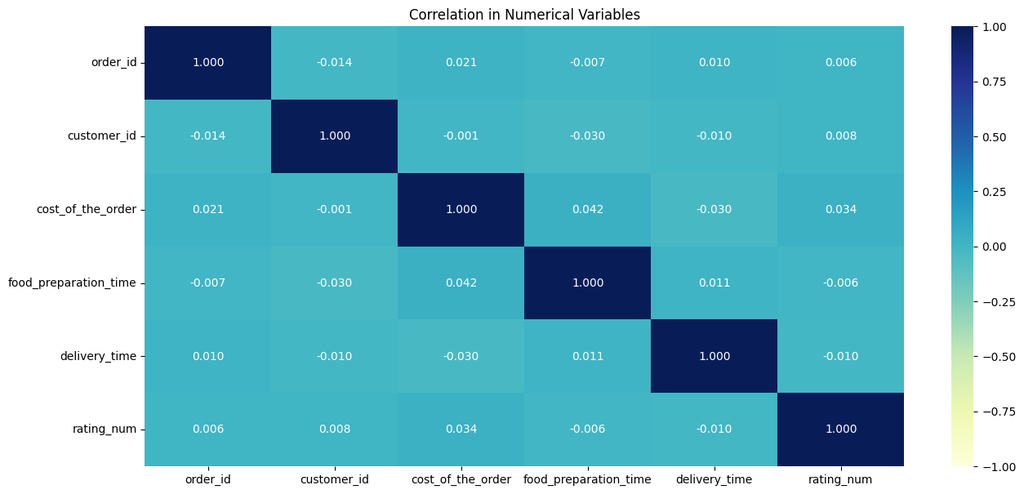

```python
# Let's start by looking at the general correlation of the numerical values in the data frame using a heatmap.
# This is a great way to represent the correlation for each column in the data frame.

plt.figure(figsize=(15, 7))   # Plot size
sns.heatmap(df_numrating_copy.corr(numeric_only=True), annot=True, vmin=-1, vmax=1, fmt=".3f", cmap='YlGnBu');   # Heatmap of the Data Frame
plt.title("Correlation in Numerical Variables")   # Title of the Graph
plt.show()
```

- From the heatmap, there does not seem to be a strong correlation between the numerical variables.
- However, one strategy is to analyze each categorical variable and compare them against the numerical ones.

#### Restaurant Revenue Analytics

- Let's start by analyzing the restaurants.
- It does not make sense to compare each restaurant with order_id, customer_id, or cuisine_type as this would not provide insightful information.
- It makes the most sense to compare the top 15 most expensive restaurants per order, the number of orders they received, and the ratings they received.

```python
# Group by 'restaurant_name' and aggregate multiple columns.
top_restaurants_stats = df.groupby('restaurant_name').agg({
    'cost_of_the_order': 'mean',  # Mean cost of the order
    'customer_id': 'count',       # Total number of orders
    'rating': lambda x: x.mode()  # Mode of ratings
})

# Sort the restaurants based on their mean cost of the order.
top_restaurants_stats_sorted = top_restaurants_stats.sort_values(by='cost_of_the_order', ascending=False).head(15)
print(top_restaurants_stats_sorted)
```

```
                            cost_of_the_order  customer_id          rating
restaurant_name
Kambi Ramen House                      32.930            1               5
Emporio                                31.430            1       Not given
Bhatti Indian Grill                    31.115            2  [5, Not given]
Haru Gramercy Park                     29.830            1               5
Lucky Strike                           29.250            1               4
Il Bambino                             29.250            1               4
Sarabeth's                             29.133            3       [3, 4, 5]
Rohm Thai                              29.100            1       Not given
Klong                                  29.050            1               5
67 Burger                              29.050            1               5
Song Thai Restaurant & Bar             26.700            2               5
Socarrat Paella Bar                    25.220            1               5
Byblos Restaurant                      24.735            2  [3, Not given]
Posto                                  24.250            1       Not given
Philippe Chow                          24.200            1               5
```

```python
# We can take this a step further and now compare the top 15 restaurants in terms of total revenue against the same variables.

# Group by 'restaurant_name' and aggregate multiple columns.
top_restaurants_stats = df.groupby('restaurant_name').agg({
    'cost_of_the_order': 'sum',  # Total cost of the orders (total revenue)
    'customer_id': 'count',      # Total number of orders
    'rating': lambda x: x.mode() # Mode of ratings
})

# Sort the restaurants based on their total revenue.
top_restaurants_stats_sorted = top_restaurants_stats.sort_values(by='cost_of_the_order', ascending=False).head(15)
print(top_restaurants_stats_sorted)
```

```
                               cost_of_the_order  customer_id          rating
restaurant_name
Shake Shack                             3579.530          219       Not given
The Meatball Shop                       2145.210          132               5
Blue Ribbon Sushi                       1903.950          119       Not given
Blue Ribbon Fried Chicken               1662.290           96  [5, Not given]
Parm                                    1112.760           68       Not given
RedFarm Broadway                         965.130           59  [5, Not given]
RedFarm Hudson                           921.210           55       Not given
TAO                                      834.500           49       Not given
Han Dynasty                              755.290           46       Not given
Blue Ribbon Sushi Bar & Grill            666.620           44       Not given
Rubirosa                                 660.450           37       Not given
Sushi of Gari 46                         640.870           37       Not given
Nobu Next Door                           623.670           42       Not given
Five Guys Burgers and Fries              506.470           29  [5, Not given]
Momoya                                   492.130           30               4
```

- By comparing the top 15 most expensive restaurants per order, we see that these restaurants tend to have fewer orders but higher individual order costs. Many of these restaurants also have high ratings, indicating customer satisfaction despite the high prices.
- When comparing the top 15 restaurants in terms of total revenue, we notice a close correlation between the popularity of restaurants and their total profit.
- Shake Shack, The Meatball Shop, and Blue Ribbon Sushi are among the highest revenue-generating restaurants, despite some having a large number of 'Not given' ratings.
- More expensive restaurants often have fewer orders but tend to receive higher ratings and fewer 'Not given' ratings.
- These insights suggest that customers may prefer more affordable or faster food delivery options for regular orders, reserving visits to more expensive restaurants for special occasions. This behavior can guide marketing strategies and promotional offers to maximize revenue and customer satisfaction.

#### Cuisine Type Analytics

- Here it would be impractical to use the previous method. Therefore, we will start by using some categorical visual representations such as box plots that will help us visualize and gain some insights.

##### Cuisine Type and Cost of the Order

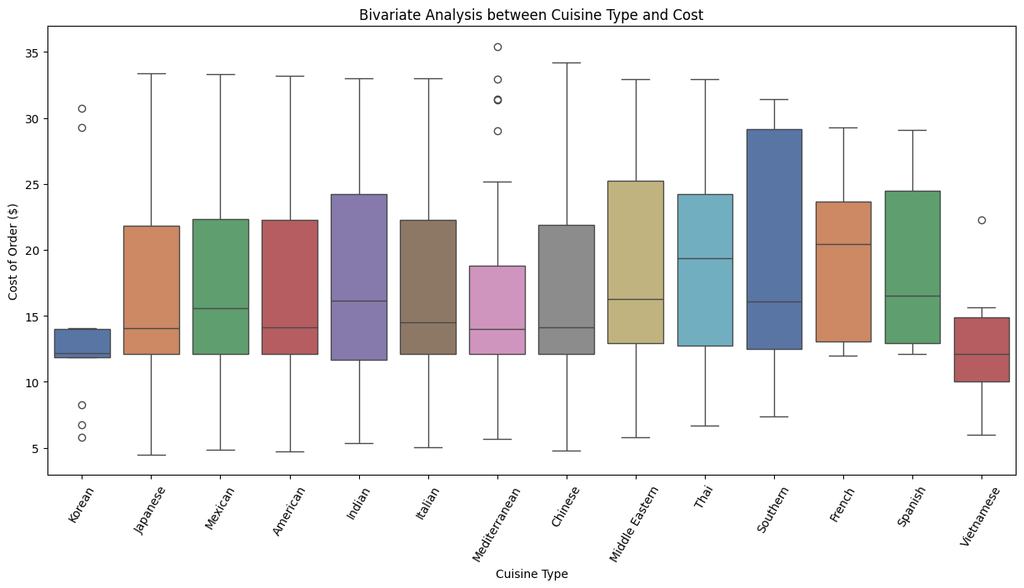

```python
# Plotting the relationship between Cuisine type and cost of the orders

plt.figure(figsize=(15, 7))   # Plot size
sns.boxplot(data=df, x='cuisine_type', y='cost_of_the_order', palette='deep'); # Boxplot of cuisine type and cost of the order
plt.title("Bivariate Analysis between Cuisine Type and Cost") # Title of the Graph
plt.xlabel('Cuisine Type')   # Title of the x-axis
plt.ylabel('Cost of Order ($)')  # Title of the y-axis
plt.xticks(rotation=60)  # Rotation of the x axis legend for clarity
plt.show()
```

##### Cuisine Type and Food Preparation Time

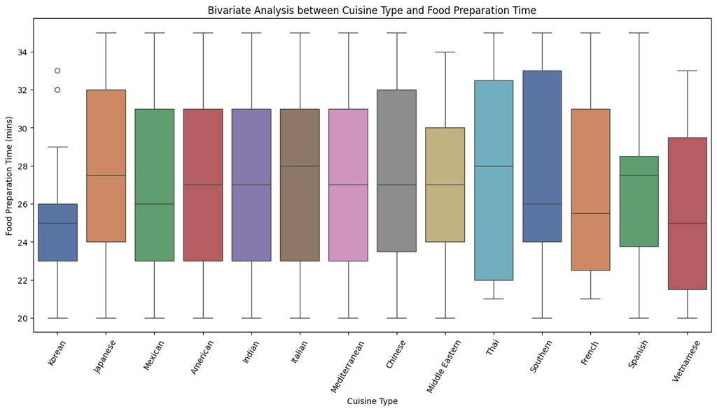

```python
# Plotting the relationship between Cuisine type and Preparation time

plt.figure(figsize=(15, 7))   # Plot size
sns.boxplot(data=df, x='cuisine_type', y='food_preparation_time', palette='deep');   # Boxplot of cuisine type and Food Preparation Time
plt.title("Bivariate Analysis between Cuisine Type and Food Preparation Time")   # Title of the Graph
plt.xlabel('Cuisine Type')   # Title of the x-axis
plt.ylabel('Food Preparation Time (mins)')  # Title of the y-axis
plt.xticks(rotation=60)  # Rotation of the x axis legend for clarity
plt.show()
```

- There are noticeable cost outliers for Korean, Mediterranean, and Vietnamese cuisines, indicating some higher-priced orders within these categories.
- The cost of the majority of orders for all cuisine types is under `$29`.
- The median cost for most cuisine types is under `$20`, suggesting that most orders are relatively affordable.
- Food preparation times for most cuisine types range from approximately 20 to 36 minutes.
- The majority of orders fall within a preparation time of 22 to 33 minutes.
- The median preparation time across different cuisine types is quite similar, ranging from 25 to 28 minutes, indicating a consistent preparation process.
- These insights can help the company understand the cost dynamics and preparation time expectations for different cuisine types, allowing for better resource planning and customer service improvements.

#### Day of the Week Analytics

##### Day of the Week and Delivery Time

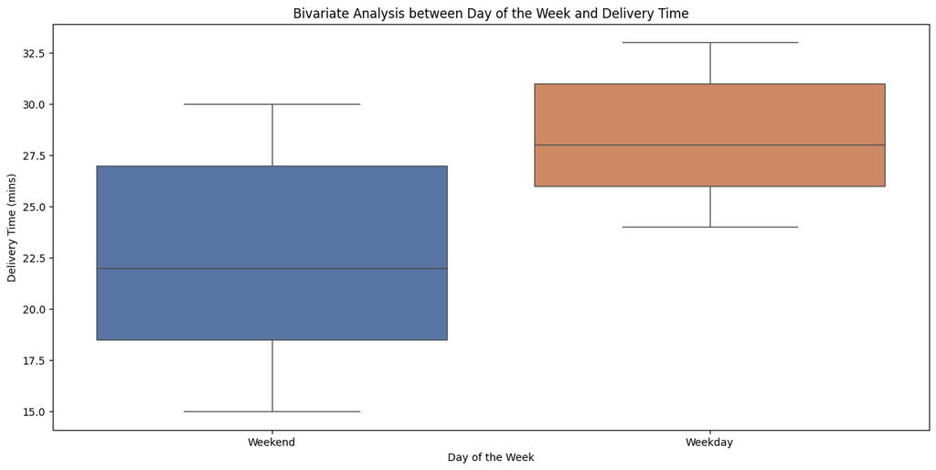

```python
# This can give us insights into whether the delivery time varies depending on whether it is a weekend or a weekday.

plt.figure(figsize=(15, 7))   # Plot size
sns.boxplot(data=df, x='day_of_the_week', y='delivery_time', palette='deep');   # Boxplot of Day of the Week and Delivery Time
plt.title("Bivariate Analysis between Day of the Week and Delivery Time")   # Title of the Graph
plt.xlabel('Day of the Week')   # Title of the x-axis
plt.ylabel('Delivery Time (mins)')   # Title of the y-axis
plt.show()
```

- Delivery times during weekdays have a narrower range with higher minimum and maximum values.
- Delivery times during weekends have a broader range but lower maximum values.
- This suggests that on weekends, delivery personnel might be rushing to complete more orders due to increased demand, while on weekdays, delivery times are more consistent, potentially due to traffic conditions or work schedules.

##### Day of the Week and Food Preparation Time

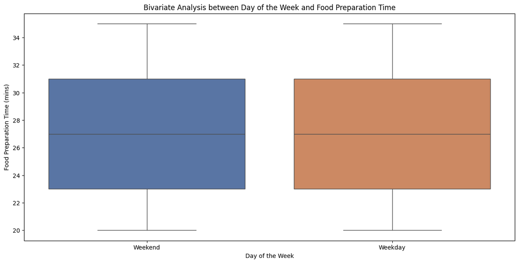

```python
# This can give us insights into whether the food preparation time varies depending on whether it is a weekend or a weekday.

plt.figure(figsize=(15, 7))  # Plot size
sns.boxplot(data=df, x='day_of_the_week', y='food_preparation_time', palette='deep');  # Boxplot of Day of the Week and Food Preparation Time
plt.title("Bivariate Analysis between Day of the Week and Food Preparation Time")  # Title of the Graph
plt.xlabel('Day of the Week')  # Title of the x-axis
plt.ylabel('Food Preparation Time (mins)')  # Title of the y-axis
plt.show()
```

- The food preparation time remains consistent regardless of whether it is a weekday or weekend.
- This indicates that kitchen operations are steady and not significantly impacted by the day of the week.

##### Day of the Week and Cost of the Order

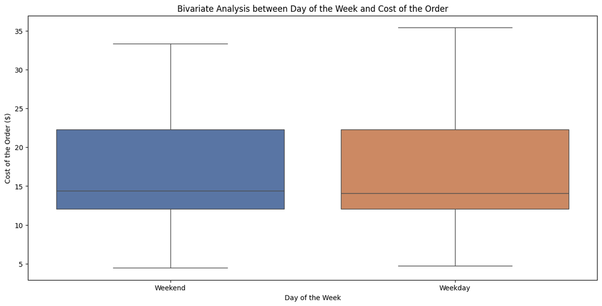

```python
# This can give us insights into whether the cost of the orders varies depending on whether it is a weekend or a weekday.

plt.figure(figsize=(15, 7))   # Plot size
sns.boxplot(data=df, x='day_of_the_week', y='cost_of_the_order', palette='deep');  # Boxplot of Day of the Week and Cost of the Order
plt.title("Bivariate Analysis between Day of the Week and Cost of the Order")  # Title of the Graph
plt.xlabel('Day of the Week')  # x-axis label
plt.ylabel('Cost of the Order ($)')  # y-axis label
plt.show()
```

#### Rating Analytics

- There is some multivariate analysis that can be done with respect to rating. One of the main things that comes to mind is posing the question of whether or not the rating has a relationship with the food preparation time, delivery time, cost of the order, and whether it’s a weekend or a weekday.

##### Rating and Food Preparation Time

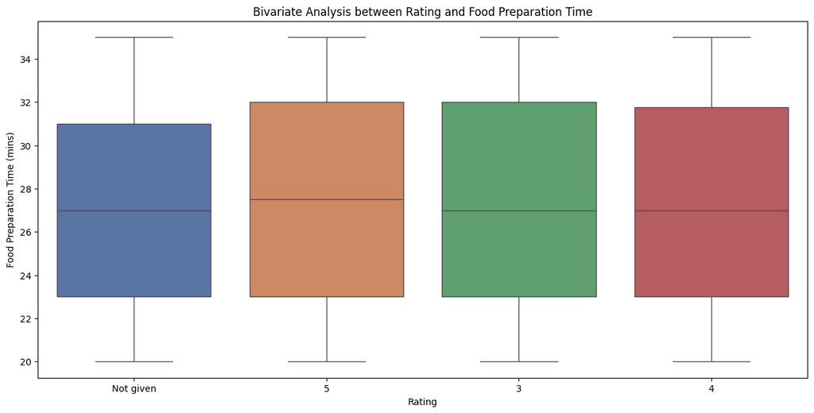

```python
# This can give us insights into whether there is a relationship between the rating and the food preparation time.

plt.figure(figsize=(15,7))                                                      # Plot size
sns.boxplot(data=df, x='rating', y='food_preparation_time', palette='deep');  # Visualizing the boxplot between Rating and Food Preparation Time
plt.title("Bivariate Analysis between Rating and Food Preparation Time")  # Title of the Graph
plt.xlabel('Rating')  # Title of the x-axis
plt.ylabel('Food Preparation Time (mins)')  # Title of the y-axis
plt.show()
```

##### Rating and Delivery Time

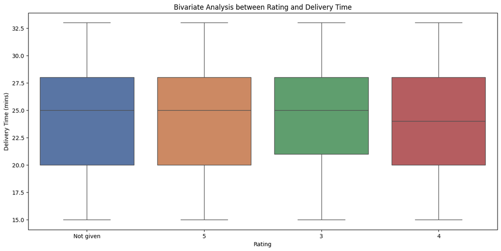

```python
# This can give us insights into whether there is a relationship between the rating and the delivery time.

plt.figure(figsize=(15, 7))   # Plot size
sns.boxplot(data=df, x='rating', y='delivery_time', palette='deep');  # Visualizing the boxplot between Rating and Delivery Time.
plt.title("Bivariate Analysis between Rating and Delivery Time")  # Title of the Graph
plt.xlabel('Rating')   # Title of the x-axis
plt.ylabel('Delivery Time (mins)')  # Title of the y-axis
plt.show()
```

##### Rating and Cost

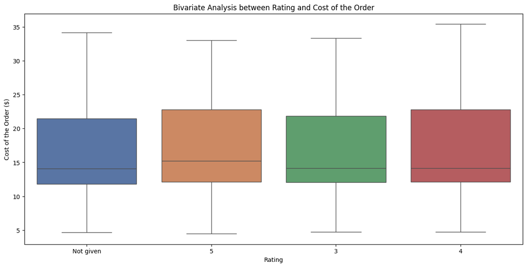

```python
# This can give us insights into whether there is a relationship between the rating and the cost of the order.

plt.figure(figsize=(15, 7))   # Plot size
sns.boxplot(data=df, x='rating', y='cost_of_the_order', palette='deep');  # Visualizing the boxplot between Rating and Cost of the Order.
plt.title("Bivariate Analysis between Rating and Cost of the Order")  # Title of the Graph
plt.xlabel('Rating')  # Title of the x-axis
plt.ylabel('Cost of the Order ($)')  # Title of the y-axis
plt.show()
```

### **Question 13:** The company wants to provide a promotional offer in the advertisement of the restaurants. The condition to get the offer is that the restaurants must have a rating count of more than 50 and the average rating should be greater than 4. Find the restaurants fulfilling the criteria to get the promotional offer. [3 marks]

- To be able to answer this question, first we need to calculate the count of ratings, the mean rating for each restaurant, and finally, we filter by the conditions.
- It is worth pointing out that in this case is better to create a new data frame copy which drops the null and non given values so that when calculating the mean ratings we are only taking into consideration the orders that actually got a rating.

```python
# Copying data to another variable to avoid any changes to the original data
df_numrating_droppednull = df.copy()

# Dropping rows where the rating is 'Not given'
df_numrating_droppednull.drop(df_numrating_droppednull[df_numrating_droppednull['rating'] == "Not given"].index, inplace=True)

# Display the summary of the ratings column to confirm changes
df_numrating_droppednull['rating'].describe()
```

```
count     1162
unique       3
top          5
freq       588
Name: rating, dtype: object
```

```python
# Calculate the count of ratings for each restaurant using the value_counts() method
restaurants_ratingcount = df_numrating_droppednull['restaurant_name'].value_counts()

# Calculate the mean rating for each restaurant using the groupby() function and mean method
restaurants_mean_rating = df_numrating_droppednull.groupby('restaurant_name')['rating'].mean()

# Filter the restaurants based on the conditions: a rating count of more than 50 and an average rating greater than 4
eligible_restaurants = restaurants_ratingcount[(restaurants_ratingcount > 50) & (restaurants_mean_rating > 4)]

# Display the eligible restaurants
print("The restaurants eligible for the promotional offer that have a rating count of more than 50 and an average rating greater than 4 are:")
print(eligible_restaurants)
```

```
The restaurants eligible for the promotional offer that have a rating count of more than 50 and an average rating greater than 4 are:
Shake Shack                  133
The Meatball Shop             84
Blue Ribbon Sushi             73
Blue Ribbon Fried Chicken     64
Name: restaurant_name, dtype: int64
```

#### Observations:

- The analysis identified four restaurants eligible for the promotional offer:
  - Shake Shack: 133 ratings
  - The Meatball Shop: 84 ratings
  - Blue Ribbon Sushi: 73 ratings
  - Blue Ribbon Fried Chicken: 64 ratings
- These restaurants have a substantial count of ratings (more than 50) and maintain high average ratings (greater than 4), indicating a consistent level of customer satisfaction. The selected restaurants have a strong customer base and positive reputation, making them potentially attractive candidates for promotional offers.
- Some of the eligible restaurants appear to be well-known chains or popular establishments, such as Shake Shack and The Meatball Shop. Offering a promotional offer to these restaurants could potentially attract more customers or incentivize repeat visits, especially considering their high average ratings and significant customer base.
- Filtering out entries with missing ratings ensures that our analysis is based on reliable and meaningful data. Including entries with missing ratings could have affected the count and mean rating calculations, potentially leading to inaccurate results and incorrect identification of eligible restaurants.

### **Question 14:** The company charges the restaurant 25% on the orders having cost greater than 20 dollars and 15% on the orders having cost greater than 5 dollars. Find the net revenue generated by the company across all orders. [3 marks]

- To achieve this, we need to calculate the revenue from orders that cost more than `$20`, then find the ones that cost more than `$5` but less than `$20`.
- Once we get these amounts, we will take 25% of the total cost for orders greater than `$20` and 15% of the total cost for orders greater than `$5` but less than `$20`.
- Finally, we add these two values to get the net revenue.

```python
# Calculate revenue for orders above $20
revenue_above_20 = df[df['cost_of_the_order'] > 20]['cost_of_the_order'].sum() * 0.25

# Calculate revenue for orders above $5 (but not above $20)
revenue_between_5_and_20 = df[(df['cost_of_the_order'] > 5) & (df['cost_of_the_order'] <= 20)]['cost_of_the_order'].sum() * 0.15

# Calculate total net revenue
net_revenue = revenue_above_20 + revenue_between_5_and_20

print("Net revenue generated by the company across all orders: $", net_revenue)
```

```
Net revenue generated by the company across all orders: $ 6166.303
```

#### Observations:

- The total net revenue generated by the company across all orders is `$6,166.30`.
- The revenue calculation method used in this approach directly considers the cost of each order and applies the respective charging percentages based on the order's cost range.
- The majority of the revenue comes from orders above `$20`, as they are charged at a higher percentage (25%) compared to orders between `$5` and `$20` (charged at 15%).
- Analyzing trends in net revenue over time can help the company make strategic decisions, such as adjusting pricing strategies or targeting promotional offers to increase revenue.
- The company may use this net revenue figure as a key performance indicator (KPI) to track its financial performance and measure progress towards its business goals.

### **Question 15:** The company wants to analyze the total time required to deliver the food. What percentage of orders take more than 60 minutes to get delivered from the time the order is placed? (The food has to be prepared and then delivered.) [2 marks]

```python
# For this we will need to create a new dataframe. We will copy the df_numrating_copy and add a new column that is the sum
# of Food Preparation Time and Delivery time. Then we will need to filter the orders that take more than 60 minute and
# get the percentage out of it.

# Create a copy of the dataframe
df_totaltime = df.copy()

# Calculate the total time required for each order (food preparation time + delivery time) and create a new row in the new Data Frame
df_totaltime['total_time'] = df_totaltime['food_preparation_time'] + df_totaltime['delivery_time']

# Display the New Data Frame
df_totaltime
```

|  | order_id | customer_id | restaurant_name | cuisine_type | cost_of_the_order | day_of_the_week | rating | food_preparation_time | delivery_time | total_time |
| --- | --- | --- | --- | --- | --- | --- | --- | --- | --- | --- |
| 0 | 1477147 | 337525 | Hangawi | Korean | 30.750 | Weekend | Not given | 25 | 20 | 45 |
| 1 | 1477685 | 358141 | Blue Ribbon Sushi Izakaya | Japanese | 12.080 | Weekend | Not given | 25 | 23 | 48 |
| 2 | 1477070 | 66393 | Cafe Habana | Mexican | 12.230 | Weekday | 5 | 23 | 28 | 51 |
| 3 | 1477334 | 106968 | Blue Ribbon Fried Chicken | American | 29.200 | Weekend | 3 | 25 | 15 | 40 |
| 4 | 1478249 | 76942 | Dirty Bird to Go | American | 11.590 | Weekday | 4 | 25 | 24 | 49 |
| ... | ... | ... | ... | ... | ... | ... | ... | ... | ... | ... |
| 1893 | 1476701 | 292602 | Chipotle Mexican Grill $1.99 Delivery | Mexican | 22.310 | Weekend | 5 | 31 | 17 | 48 |
| 1894 | 1477421 | 397537 | The Smile | American | 12.180 | Weekend | 5 | 31 | 19 | 50 |
| 1895 | 1477819 | 35309 | Blue Ribbon Sushi | Japanese | 25.220 | Weekday | Not given | 31 | 24 | 55 |
| 1896 | 1477513 | 64151 | Jack's Wife Freda | Mediterranean | 12.180 | Weekday | 5 | 23 | 31 | 54 |
| 1897 | 1478056 | 120353 | Blue Ribbon Sushi | Japanese | 19.450 | Weekend | Not given | 28 | 24 | 52 |

1898 rows × 10 columns

```python
# Analyze the data type of the new column of the data frame
df_totaltime.info()
```

```
<class 'pandas.core.frame.DataFrame'>
RangeIndex: 1898 entries, 0 to 1897
Data columns (total 10 columns):
 #   Column                 Non-Null Count  Dtype
---  ------                 --------------  -----
 0   order_id               1898 non-null   int64
 1   customer_id            1898 non-null   int64
 2   restaurant_name        1898 non-null   object
 3   cuisine_type           1898 non-null   object
 4   cost_of_the_order      1898 non-null   float64
 5   day_of_the_week        1898 non-null   object
 6   rating                 1898 non-null   object
 7   food_preparation_time  1898 non-null   int64
 8   delivery_time          1898 non-null   int64
 9   total_time             1898 non-null   int64
dtypes: float64(1), int64(5), object(4)
memory usage: 148.4+ KB
```

```python
# Calculate the percentage of orders where the total time exceeds 60 minutes

percent_above60mins = (df_totaltime[df_totaltime['total_time'] > 60].shape[0] / df.shape[0]) * 100
print("The percentage of orders taking more than 60 minutes for delivery is:", round(percent_above60mins, 2), "%")
```

```
The percentage of orders taking more than 60 minutes for delivery is: 10.54 %
```

#### Observations:

- Approximately 10.54% of orders take more than 60 minutes for delivery, from the time the order is placed until the food is delivered.
- This percentage indicates that a significant portion of orders experience longer delivery times, which may have implications for customer satisfaction and retention.
- Longer delivery times could potentially lead to customer dissatisfaction, negative reviews, and decreased customer loyalty.
- Factors contributing to longer delivery times could include high order volumes, traffic conditions, distance from the restaurant to the delivery location, and efficiency of food preparation and delivery processes.
- Analyzing trends in delivery times over time can help identify patterns and areas for improvement in the delivery process, such as optimizing routes, increasing staffing during peak hours, and streamlining food preparation workflows.
- Addressing issues related to longer delivery times can enhance overall customer experience and contribute to the success and competitiveness of the food delivery business in the market.

### **Question 16:** The company wants to analyze the delivery time of the orders on weekdays and weekends. How does the mean delivery time vary during weekdays and weekends? [2 marks]

- To acheive this we first need to separate the data in two subsets, Weekdays and Weekends.
- And then, we calculate the mean delivery time for weekdays and weekends

```python
# Separate the data into two subsets: one for weekdays and one for weekends
weekday_data = df_totaltime[df_totaltime['day_of_the_week'] == 'Weekday']
weekend_data = df_totaltime[df_totaltime['day_of_the_week'] == 'Weekend']

# Calculate the mean delivery time for weekdays and weekends
mean_dt_weekday = weekday_data['delivery_time'].mean()
mean_dt_weekend = weekend_data['delivery_time'].mean()

print("The mean delivery time on weekdays:", round(mean_dt_weekday, 2), "minutes.")
print("The mean delivery time on weekends:", round(mean_dt_weekend, 2), "minutes.")
```

```
The mean delivery time on weekdays: 28.34 minutes.
The mean delivery time on weekends: 22.47 minutes.
```

#### Observations:

- The mean delivery time on weekdays is approximately 28.34 minutes, while on weekends it is around 22.47 minutes. There is a noticeable difference in the mean delivery times between weekdays and weekends, with weekends having shorter delivery times on average.
- This variation in delivery times between weekdays and weekends suggests that different factors may influence delivery efficiency and speed on different days of the week.
- On weekdays, delivery times may be longer due to higher order volumes during peak hours, increased traffic congestion, and potentially fewer available delivery staff.
- Understanding these differences in delivery times can help the company optimize its delivery operations, allocate resources more effectively, and provide better service to customers.

### Recommendations:

1. Operational Recomendations:
   - Improve delivery efficiency, particularly on weekdays, by optimizing delivery routes to reduce travel time.
2. Marketing and Promotions:
   - Continue offering promotional discounts to top-performing restaurants such as Shake Shack, The Meatball Shop, Blue Ribbon Sushi, and Blue Ribbon Fried Chicken to attract more customers.
   - Implement weekend specials focused on popular cuisines like American to boost sales further as majority of the sales are on Weekends.
   - Develop special offers for high-rated cuisines like American and Japanese to leverage their high customer satisfaction and boost revenue.
3. Customer Experience Recomendations:
   - Enhance communication with customers regarding expected delivery times, especially during peak hours or adverse traffic conditions, to manage expectations and reduce dissatisfaction.
   - Implement a robust feedback system to gather more detailed insights into customer preferences and pain points, enabling continuous improvement in service quality. A reward program dependent on wether you are rating your orders may be a good strategy and encourage customers to rate their orders more so there is not a lot of missing values that could affect the data.
4. Revenue Growth Recomendations:
   - Continue developing loyalty programs targeting and rewarding frequent customers to encourage repeat orders and increase customer retention.
   - Take advantage of the weekends and the most popular food cuisines to boost revenue.
5. Data-Driven Decisions:
   - Continue conducting regular data analysis to monitor trends in order volumes, delivery times, and customer satisfaction. This will help the company stay agile and responsive to changing customer needs and market conditions.
   - Invest in advanced analytics and machine learning tools to gain deeper insights into customer behavior, operational efficiency, and market trends.